# P8105 - Homework 5

Joe LaRocca

2024-11-14

## Problem 1

#### Create the Birthday Simulator Function

```r
bday_sim = function(n) {
  bdays = sample(1:365, size = n, replace = TRUE)
  duplicate = length(unique(bdays)) < n
  return(duplicate)
}
```

#### Run 10,000 Iterations from Sample Size 2 to 50

```r
sim_res =
  expand_grid(
    n = c(2:50),
    iter = 1:10000
  ) |>
  mutate(res = map_lgl(n, bday_sim)) |>
  group_by(n) |>
  summarize(prob = mean(res))
```

#### Make a Plot of Sample Size vs. Probability

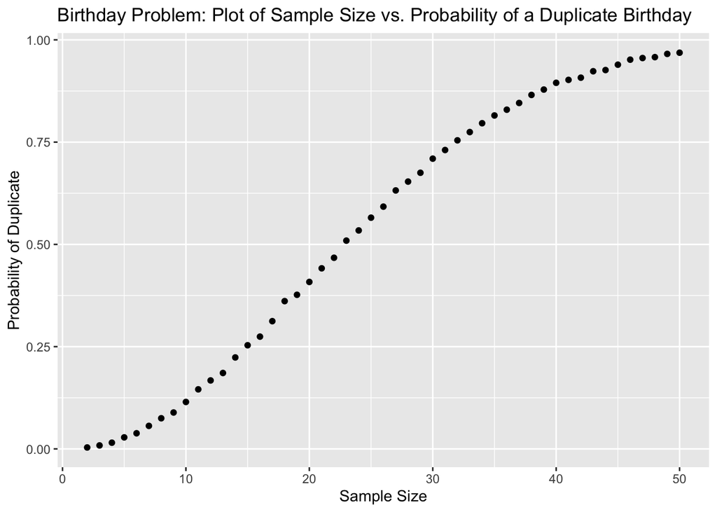

```r
sim_res |>
  ggplot(aes(x = n, y = prob)) +
  geom_point() +
  labs(
    title = "Birthday Problem: Plot of Sample Size vs. Probability of a Duplicate Birthday",
    x = "Sample Size",
    y = "Probability of Duplicate"
  )
```

The plot of sample size vs. probability of a duplicate is S-shaped, and strongly resembles a Logistic curve. The probability of a duplicate first crosses 50% at $n = 23$.

## Problem 2

#### Create a t_test function that cleans the test and selects for the data we want

```r
t_test = function(mu, n = 30, sd = 5){
  test = t.test(rnorm(n, mu, sd)) |>
    broom::tidy() |>
    select(estimate, p.value)
  return(test)
}
```

#### Run the simulation 5000 times for mu between 0 and 6 inclusive

```r
sim_res = expand_grid(
  mu = c(0:6),
  iter = c(1:5000)
) %>%
  mutate(res = map(mu, t_test))
```

#### Format the data for plotting

```r
sim_res = sim_res |>
  unnest(res) |>
  mutate(reject = p.value < 0.05)
```

#### Make Plot #1

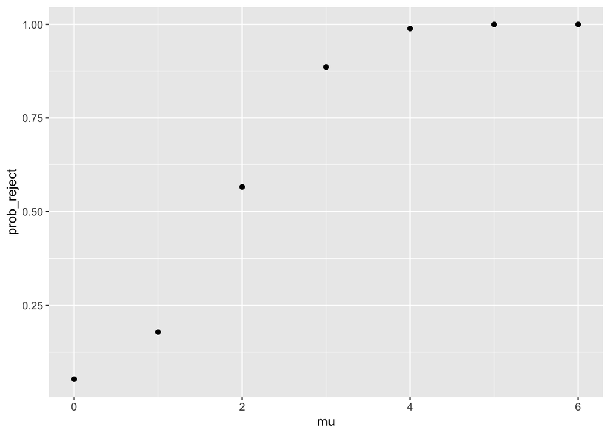

```r
sim_res |>
  select(mu, reject) |>
  group_by(mu) |>
  summarize(prob_reject = mean(reject)) |>
  ggplot(aes(x = mu, y = prob_reject)) +
  geom_point()
```

From this plot, we can see that there is a strong, positive, and nonlinear association between effect size and power. More specifically, we see the sharpest increases in power between $\mu = 1$ and $\mu = 2$ and between $\mu = 2$ and $\mu = 3$. The probability of rejection first crosses 50% at $\mu = 2$.

#### Make Plot #2

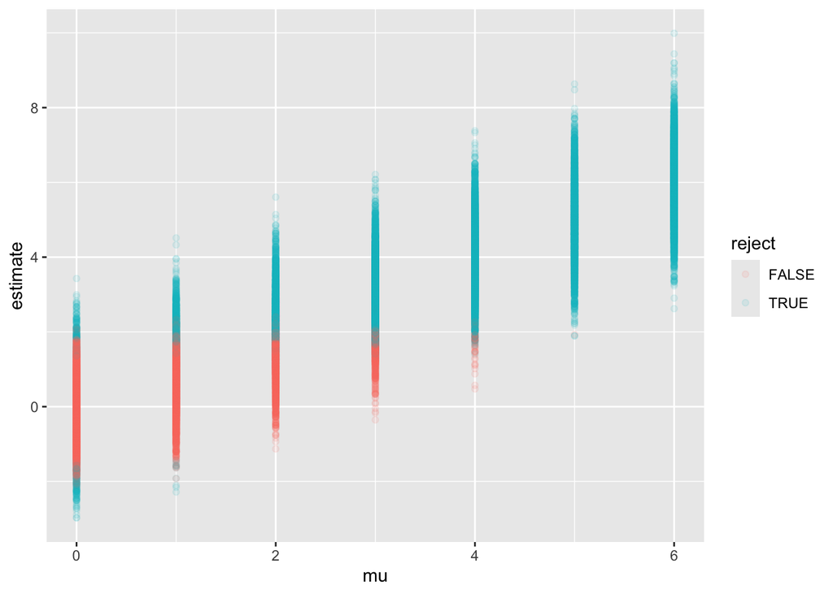

```r
sim_res |>
  ggplot(aes(x = mu, y = estimate, col = reject)) +
  geom_point(alpha = 0.1)
```

From the plot, we can see that the sample averages for each value of $\mu$ are approximately equal to the true values of $\mu$. In theory, this would be true because we know $E(X) = \mu$ and $\bar{x} = \frac{\sum_{k = 1}^n}{n}$. So, $E(\bar{x}) = E(\frac{\sum_{i = 1}^n x_i}{n}) = \frac{1}{n} E(\sum_{i = 1}^n x_i) = \frac{1}{n}(E(X_1) + E(X_2) + ... + E(X_n)) = \frac{1}{n}({n\mu}) = \mu$. In other words, the expectation of the sample mean is equal to the expectation of each individual data point, which is $\mu$.

## Problem 3

#### Upload the Data

```r
homicides = read_csv("data/homicide-data.csv")
```

#### Describing the Dataset

```r
summary(homicides$reported_date)
```

```
##      Min.   1st Qu.    Median      Mean   3rd Qu.      Max.
##  20070101  20100318  20121216  20130899  20150911 201511105
```

```r
mean(as.numeric(homicides$victim_age), na.rm = TRUE)
```

```
## [1] 31.80122
```

```r
median(as.numeric(homicides$victim_age), na.rm = TRUE)
```

```
## [1] 28
```

```r
homicides |>
  group_by(victim_race) |>
  count() |>
  summarize(prop = n/nrow(homicides))
```

```
## # A tibble: 6 × 2
##   victim_race   prop
##   <chr>        <dbl>
## 1 Asian       0.0131
## 2 Black       0.639
## 3 Hispanic    0.132
## 4 Other       0.0134
## 5 Unknown     0.0805
## 6 White       0.121
```

#### Combine city and state into a “city_state” column

```r
homicides = homicides |>
  unite(col = "city_state", city, state, sep = ", ")
```

#### Summarize to find Number of Total / Unsolved Homicides by City

```r
homicides = homicides |>
  mutate(unsolved =
      disposition == "Closed without arrest" |
      disposition == "Open/No arrest")

homicide_stats = homicides |>
  group_by(city_state) |>
  summarize(
    num_homicides = length(disposition),
    num_unsolved = sum(unsolved)
  )

homicide_stats
```

```
## # A tibble: 51 × 3
##    city_state      num_homicides num_unsolved
##    <chr>                   <int>        <int>
##  1 Albuquerque, NM           378          146
##  2 Atlanta, GA               973          373
##  3 Baltimore, MD            2827         1825
##  4 Baton Rouge, LA           424          196
##  5 Birmingham, AL            800          347
##  6 Boston, MA                614          310
##  7 Buffalo, NY               521          319
##  8 Charlotte, NC             687          206
##  9 Chicago, IL              5535         4073
## 10 Cincinnati, OH            694          309
## # ℹ 41 more rows
```

#### Create a prop_test function that tests proportion of unsolved homicides by city

```r
prop_test_interval = function(city, p = 0.5) {
  x = homicide_stats |>
    filter(city_state == city) |>
    pull(num_unsolved)

  n = homicide_stats |>
    filter(city_state == city) |>
    pull(num_homicides)

  test = prop.test(x, n, p) |>
    broom::tidy() |>
    select(estimate, conf.low, conf.high)
    return(test)
}
```

#### Find confidence interval for Baltimore

```r
homicide_stats |>
  filter(city_state == "Baltimore, MD") |>
  mutate(results = map(city_state, prop_test_interval)) |>
  unnest(results)
```

```
## # A tibble: 1 × 6
##   city_state    num_homicides num_unsolved estimate conf.low conf.high
##   <chr>                 <int>        <int>    <dbl>    <dbl>     <dbl>
## 1 Baltimore, MD          2827         1825    0.646    0.628     0.663
```

#### Find confidence interval for all cities

```r
homicide_cis = homicide_stats |>
  group_by(city_state) |>
  mutate(results = map(city_state, prop_test_interval)) |>
  unnest(results) |>
  filter(city_state != "Tulsa, AL")
homicide_cis
```

```
## # A tibble: 50 × 6
## # Groups:   city_state [50]
##    city_state      num_homicides num_unsolved estimate conf.low conf.high
##    <chr>                   <int>        <int>    <dbl>    <dbl>     <dbl>
##  1 Albuquerque, NM           378          146    0.386    0.337     0.438
##  2 Atlanta, GA               973          373    0.383    0.353     0.415
##  3 Baltimore, MD            2827         1825    0.646    0.628     0.663
##  4 Baton Rouge, LA           424          196    0.462    0.414     0.511
##  5 Birmingham, AL            800          347    0.434    0.399     0.469
##  6 Boston, MA                614          310    0.505    0.465     0.545
##  7 Buffalo, NY               521          319    0.612    0.569     0.654
##  8 Charlotte, NC             687          206    0.300    0.266     0.336
##  9 Chicago, IL              5535         4073    0.736    0.724     0.747
## 10 Cincinnati, OH            694          309    0.445    0.408     0.483
## # ℹ 40 more rows
```

#### Make Plot of Estimates and CIs

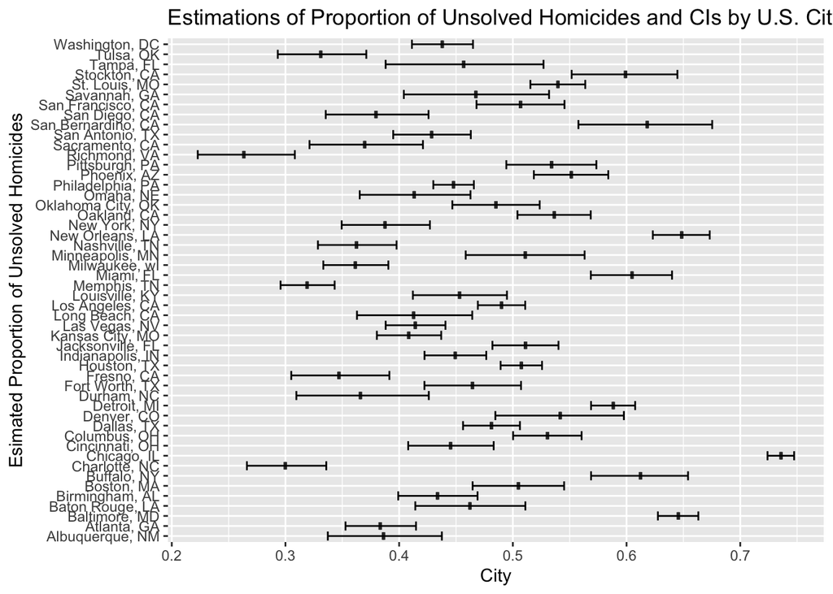

```r
homicide_cis |>
  mutate(city_state = fct_reorder(city_state, estimate)) |>
  ggplot(aes(x = city_state, y = estimate)) +
  geom_boxplot() +
  geom_errorbar(aes(ymin = conf.low, ymax = conf.high)) +
  coord_flip() +
   labs(
    x = "Esimated Proportion of Unsolved Homicides",
    y = "City",
    title = "Estimations of Proportion of Unsolved Homicides and CIs by U.S. City"
  )
```

```r
homicide_cis |>
  mutate(city_state = fct_reorder(city_state, estimate))
```

```
## # A tibble: 50 × 6
## # Groups:   city_state [50]
##    city_state      num_homicides num_unsolved estimate conf.low conf.high
##    <fct>                   <int>        <int>    <dbl>    <dbl>     <dbl>
##  1 Albuquerque, NM           378          146    0.386    0.337     0.438
##  2 Atlanta, GA               973          373    0.383    0.353     0.415
##  3 Baltimore, MD            2827         1825    0.646    0.628     0.663
##  4 Baton Rouge, LA           424          196    0.462    0.414     0.511
##  5 Birmingham, AL            800          347    0.434    0.399     0.469
##  6 Boston, MA                614          310    0.505    0.465     0.545
##  7 Buffalo, NY               521          319    0.612    0.569     0.654
##  8 Charlotte, NC             687          206    0.300    0.266     0.336
##  9 Chicago, IL              5535         4073    0.736    0.724     0.747
## 10 Cincinnati, OH            694          309    0.445    0.408     0.483
## # ℹ 40 more rows
```